# Introduction to Species Distribution Models

## What we learned from MARS

- An interaction between temperature and forest is needed
- A quandratic form of temperature is needed

## Issues yet to solve

- Observation error

## Conduct occupancy modeling

```r
library(unmarked) # This is the library for occupancy models
```

```r
# Prepare data for "unmarked"
unmarked.data <- unmarkedFrameOccu(y=data[,1:4],
                                siteCovs=data[,c('temperature','forest')],
                                obsCovs=NULL)
```

## Run "unmarked" to fit the MacKenzie et al. (2002) Occupancy Model

```r
fit <- occu(~1 ~temperature*forest + I(temperature^2)*forest,
            data=unmarked.data, knownOcc=which(rowSums(y)==1))
```

## Look at the parameter estimates

```r
summary(fit)
```

```
## $state
##                          Estimate        SE          z      P(>|z|)
## (Intercept)              4.384943 0.5080236  8.6313774 6.061749e-18
## temperature              3.692015 0.5255455  7.0251103 2.138972e-12
## forest                  -0.631143 0.9077174 -0.6953077 4.868625e-01
## I(temperature^2)        -5.895302 0.7024106 -8.3929566 4.740665e-17
## temperature:forest      -2.538355 0.8198184 -3.0962403 1.959915e-03
## forest:I(temperature^2)  5.146736 0.8855911  5.8116394 6.186399e-09
##
## $det
##                Estimate         SE         z   P(>|z|)
## (Intercept) 0.007790955 0.04084357 0.1907511 0.8487206
```

## Overall detection probability

```r
library(boot)
pobs <- inv.logit(0.007790955)
pobs.grand <- 1 - (1 - pobs) ^ 4
pobs
```

```
## [1] 0.5019477
```

```r
pobs.grand
```

```
## [1] 0.9384682
```

## Check the response curve

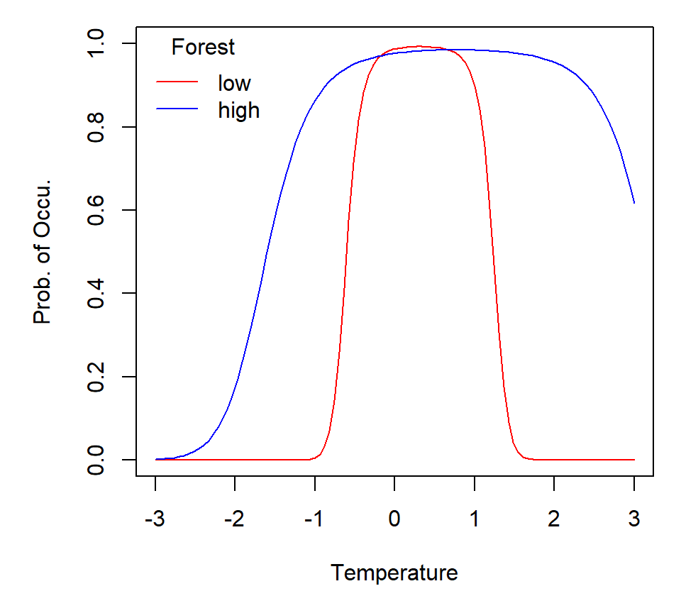

```r
rm(list=ls())
library(boot)
load('c:/A. UFL/rmeetup/est.RData')
n <- 100
xseq <- seq(-3, 3, length.out=n)
pi0 <- inv.logit(est[1,1] + est[2,1] * xseq + est[4,1] * xseq ^ 2)
pi1 <- inv.logit(est[1,1] + est[2,1] * xseq + est[4,1] * xseq ^ 2 +
                est[3,1] + est[5,1] * xseq + est[6,1] * xseq ^ 2)
par(mfrow=c(1,1))
par(mar=c(5,5,1,1))
plot(pi0 ~ xseq, type='l', ylim=c(0,1), col=2,
     xlab='Temperature', ylab='Prob. of Occu.')
lines(pi1 ~ xseq, col=4)
legend('topleft', bty='n', lty=1, col=2^c(1:2),
       legend=c('low','high'), title='Forest')
```

## Predict the distribution of lion beetles

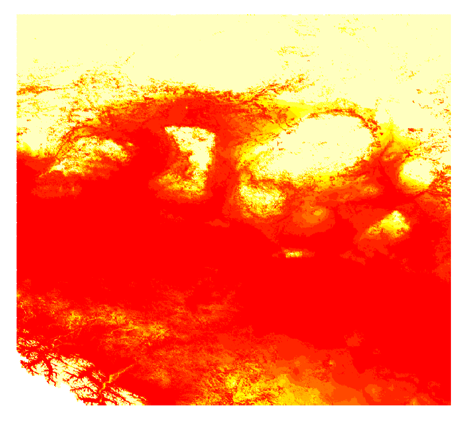

```r
library(boot)

load('c:/A. UFL/rmeetup/est.RData')
load('c:/A. UFL/2. Alberta/data/original/EnvData.km2.RData')
pi <- inv.logit(est[1,1] + est[2,1] * cov$MAT + est[4,1] * cov$MAT ^ 2 +
              est[3,1] * cov$forest + est[5,1] * cov$MAT * cov$forest +
              est[6,1] * cov$MAT ^ 2 * cov$forest)
pi.scale <- round((pi - min(pi)) / (max(pi) - min(pi)) * 9) + 1

par(mfrow=c(1,1))
par(mar=c(0,0,1,0))
par(oma=c(1,1,1,1))

plot(cov$lat ~ cov$lon, pch=19, cex=.01, axes=F,
     xlab='', ylab='',
     col=rev(heat.colors(10))[pi.scale])
```

## What did occupancy do for us?

- Estimate detection probability
- Explain beetle-environment relationships
- Predict beetle distribution

## Further reading

- Stacked Species Distribution Modelling
  - https://cran.r-project.org/web/packages/SSDM/SSDM.pdf
  - You can use this package to ensemble a number of machine learning approaches such as Generalized additive model (GAM), Multivariate adaptive regression splines (MARS), Generalized boosted regressions model (GBM), Classification tree analysis (CTA), Random forest (RF), Maximum entropy (MAXENT), Artificial neural network (ANN), and Support vector machines (SVM)

## Further reading

- Multi-species modeling
  - Interspecific similarity & undirectional interspecific interactions
    - Ovaskainen, O., Tikhonov, G., Norberg, A., Guillaume Blanchet, F., Duan, L., Dunson, D., Roslin, T. and Abrego, N., 2017. How to make more out of community data? A conceptual framework and its implementation as models and software. Ecology Letters, 20(5), pp.561-576.
  - Uni-directional interspecific interactions
    - Waddle, J.H., Dorazio, R.M., Walls, S.C., Rice, K.G., Beauchamp, J., Schuman, M.J. and Mazzotti, F.J., 2010. A new parameterization for estimating co-occurrence of interacting species. Ecological Applications, 20(5), pp.1467-1475.

## Further reading

- Spatial autocorrelation
  - Reviews
    - Dormann et al., 2007. Methods to account for spatial autocorrelation in the analysis of species distributional data: a review. Ecography, 30(5), pp.609-628.
    - Beale et al., 2010. Regression analysis of spatial data. Ecology letters, 13(2), pp.246-264.
  - Recent advances
    - Crase, B., Liedloff, A.C. and Wintle, B.A., 2012. A new method for dealing with residual spatial autocorrelation in species distribution models. Ecography, 35(10), pp.879-888.
    - Hodges, J.S. and Reich, B.J., 2010. Adding spatially-correlated errors can mess up the fixed effect you love. The American Statistician, 64(4), pp.325-334.

## Further reading

- Dynamic models
  - MacKenzie, D.I., Nichols, J.D., Hines, J.E., Knutson, M.G. and Franklin, A.B., 2003. Estimating site occupancy, colonization, and local extinction when a species is detected imperfectly. Ecology, 84(8), pp.2200-2207.
  - Dail, D. and Madsen, L., 2011. Models for estimating abundance from repeated counts of an open metapopulation. Biometrics, 67(2), pp.577-587.

## Further reading

- Spatially explicit dynamic models
  - Bled, F., Royle, J.A. and Cam, E., 2011. Hierarchical modeling of an invasive spread: the Eurasian Collared-Dove Streptopelia decaocto in the United States. Ecological Applications, 21(1), pp.290-302.
  - Hefley, T.J., Hooten, M.B., Russell, R.E., Walsh, D.P. and Powell, J.A., 2017. When mechanism matters: Bayesian forecasting using models of ecological diffusion. Ecology Letters, 20(5), pp.640-650.
  - Zhao, Q., Royle, J.A. and Boomer, G.S., 2017. Spatially explicit dynamic N-mixture models. Population Ecology, 59(4), pp.293-300.